# lecture-10-sampling-fundamentals

## M303 Sampling Fundamentals

FALL 2026 · LECTURE 10

M303

Sampling Fundamentals

Choose a sampling process that can support the marketing decision.

## Where we are

Fundamentals of Data Analysis

Hypothesis testing

Correlation and regression analysis

Secondary data

Primary data

Observational and Qualitative Methods

Surveys

Sampling

Sampling schemes

Sample size

Problem

Formulation

Research

Design

Data

Collection

Data Analysis &

Recommendation

Preliminary stages of MR

Problem  actionable management problem  research objectives  research questions  hypotheses

Decide on the type of research

Exploratory, descriptive, and causal

## Learning Objectives

You should be able to

Define sampling

Distinguish the target population, sampling frame, and sampling unit

Explain when to use a census rather than a sample

Identify possible sampling and non-sampling errors

Describe the three stages of the sampling process

Compare probability and non-probability sampling procedures

## Previous-class review

01

In general, editing and coding are easier in closed-ended questions compared to open-ended ones.

02

Response rates of open-ended questions are lower in general compared to closed-ended questions.

03

Open-ended questions are more open to interviewer bias.

04

Asking more questions tends to decrease the response rates in questionnaires.

05

In a typical questionnaire, the questions related to demographics should be asked at the very beginning.

06

It is recommended to ask engaging questions in the middle.

## Previous-class review (continued)

When was the last time you upgraded your computer and tablet?

Now that you've seen how you can save time, would you buy our service?

What is your current age? • 20 to 30 • 31 to 40 • 41 to 50

What is your opinion of Jimmy John’s sandwiches?

Pretty good

Great

Fantastic

Incredible

The Best Ever

Jimmy John’s

## What is sampling?

The process of obtaining information from a subset of a larger group

Population

The total group of people from whom we need to obtain information

Census

Data about every member of the population

Sample

A subset of the population

## What is the target population, the sampling frame and unit?

Target Population

Define the relevant population

Specify the characteristics from whom information is needed

Sampling Frame

A list of members of the population from which the sample may be drawn

Sampling Unit

Group that is selected as the sample

## When should you use a census rather than a sample?

Objective:

Learn the proportion of college students watching the TV Show “House of the Dragon” in Bloomington, IN

How to achieve this?

college students in Bloomington, IN

## When is a census appropriate?

One should use census if

Population size is reasonably small

Information is needed from everybody in the population

Cost of making incorrect decisions is high

Sampling errors are high

## When should you use a sample?

One should use sample if

Population is big

Both cost and time associated with obtaining information from the entire population is high

Quick decision is needed

Response quality is important

Census is impossible

## What are the errors in sampling?

Total Error

Difference between the true value and the observed value of a variable

Sampling Error

Errors due to sampling

Non-sampling Error

Errors observed in both a census and a sample

Measurement errors, data-analysis errors, etc.

## What are the stages of the sampling process?

Identify the target population

↓

Determine the sampling frame

**Reconcile**population–sampling-frame differencesFeed the correction back into the frame.

↓

**Select a sampling procedure**

Probability sampling

- Simple random
- Stratified
- Systematic
- Cluster
- Multistage

Non-probability sampling

- Convenience
- Judgmental
- Quota
- Snowball

↓

Determine the relevant sample size

↓

Execute sampling

↓

Collect data from respondents

**Handle**the nonresponse problemFeed the response plan into data collection.

↓

Information for decision making

## What are the stages of the sampling process? Determining the target population

Example:

A target population for a Bloomington toy store can be deﬁned as “all households with children living in Bloomington.”

Is this definition clearly specified?

children?

Bloomington?

## What are the stages of the sampling process? Determining the sampling frame

Sampling Frame:

List of population members used to obtain a sample

Dealing with population sampling frame differences:

Subset problem

Want to survey Fortune 1000 firms but only have access to Fortune 500

Superset problem

Want to survey Dove customers but only have access to Unilever list

Intersection problem

Want to survey people with at least a college degree but only have access to graduate students.

Reebok wants to survey individuals who have purchased Reebok shoes

Individuals who have purchased

[figure not shown]

## Probability vs. non-probability sampling

Non-probability sampling

Not every population member has a known, nonzero chance of being selected

Probability sampling

Every population member has a known, nonzero chance of being selected

Advantages

Can produce representative samples

Supports statistical generalization to the population

Disadvantages

Can be expensive

Requires time and effort to design and execute

## What are the sampling procedures?

Sampling procedures

Probability sampling

Non-probability sampling

Convenience

Quota

Snowball

Judgmental

Simple random

Stratified

Cluster

Systematic

Proportionate

Disproportionate

Directly

Inversely

## Probability sampling: simple random sampling (SRS)

Each member of the population has an equal probability to be selected

Population:

12 people

Sample:

4 respondents

Write 12 numbers of 1 to 12, then pick 4 numbers out of the hat.

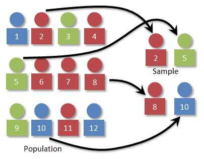

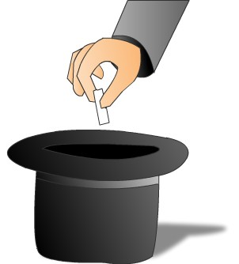

## Probability sampling: systematic sampling

Sample in a systematic way

Be aware of the regularities in the list.

A list of couples in a dance club routinely places the female’s name first.

Then selecting every tenth name will result in a sample of all males

This technique is commonly used in telephone interviews.

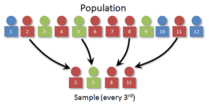

## Probability sampling: stratified sampling

Identify salient demographic or classification factors correlated with the behavior of interest. Example: Heavy buyers generally come from high-income, college-educated households.

Determine what proportions of the population fall into the various groups (called strata).

Choose proportional or disproportional allocation with respect to the stratum sizes.

Select simple random samples (SRS) from each stratum.

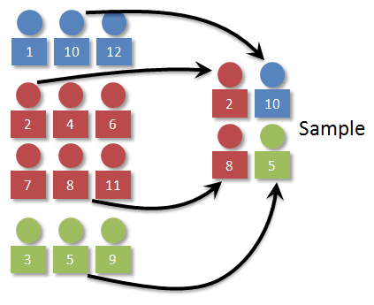

## What are the types of stratified sampling?

Proportionate Stratified Sampling

Number of objects chosen from each group (or stratum) is proportional to the corresponding numbers in the population

Directly Proportional or Inversely Proportional stratified sampling

Disproportionate Stratified Sampling

Sample size in each group (or stratum) is not proportional to the respective sizes in the population

Used when multiple groups are compared and respective group sizes are small

## Example: Directly proportional stratified sampling

**Complete the 10% directly proportional allocation.**Each stratum keeps the same sampling fraction.

| Consumer type | Group size | 10% directly proportional sample size |
| --- | --- | --- |
| Brand-loyal | 400 |  |
| Variety-seeking | 200 |  |
| Total | 600 |  |

## Example: inversely proportional stratified sampling

Target population **600 beverage consumers: 400 light drinkers and 200 heavy drinkers**

The researcher needs proportionally greater representation from heavy drinkers, so that group receives the higher sampling fraction.

For a 10% inversely proportional stratified sample, how many people should be sampled from each group?

## Probability sampling: cluster sampling

Population is partitioned into mutually exclusive clusters

Randomly select some clusters

Members in the selected clusters are all selected

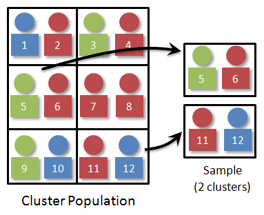

## Stratified vs. cluster sampling

Stratified sampling

Cluster sampling

**How groups differ**Divide the population into groups that differ from one another: heterogeneity among groups.

**How groups compare**Divide the population into similar groups: homogeneity across groups.

**Which groups enter**All groups are included.

**Which groups enter**Randomly select groups.

**Where sampling occurs**Randomly sample within each group; members within a stratum are relatively homogeneous.

**Where variation sits**Clusters are heterogeneous within; sampling occurs between groups.

**Primary benefit**Increases representativeness.

**Primary benefit**Reduces sampling costs.

## Nielsen Method

http://youtu.be/2AZ3ftjcJU4

Which sampling method best describes the procedure used by Nielsen TV ratings?

A. Simple Random Sampling

B. Systematic Sampling

C. Stratified Sampling

D. Cluster Sampling

E. Non-probability Sampling

[Open source media ↗](http://youtu.be/2AZ3ftjcJU4)

## Non-probability sampling

Convenience

Procedure of obtaining the objects that are most conveniently available.

Quota

Important characteristics in the same proportion as in the population

Snowball

Initial respondents are selected by probability methods. Additional respondents are obtained from information provided by the initial respondents.

Judgment

An experienced individual selects the sample based on judgment about the appropriate required characteristics.

## What are the pros, cons, and uses of non-probability sampling?

Costs and trouble of developing sampling frame are eliminated

Results might contain biases

Used in:

The exploratory stages of a research project

Pre-testing a questionnaire

Dealing with a homogeneous population

When a researcher lacks statistical knowledge

## In-Class Exercise

For your group marketing problem, identify your target population. Then:

Define your sampling frame– who are you going to sample and from where?

Select a sampling procedure: probability vs. non-probability and which specific type (simple random, stratified, convenience, etc.)

What problems and biases will you run into? Superset, intersection, subset? Selection bias?

How can you mitigate these?

## To sum up

Sampling

The process of obtaining information from a subset of a larger group

Census vs. Sample

Total Error = Sampling Error + Non-Sampling Error

Sampling Process

Step 1: Determine the Target Population

Step 2: Determine the Sampling Frame

Step 3: Choose a Sampling Procedure

Sampling Procedure

Probabilistic vs. non-probabilistic sampling

## Next class

COMING UP

Sample Size and Statistical Theory I

**Core question**How do representativeness, variability, confidence, and precision shape sample-size decisions?